# Cinema

Alejandro Gutiérrez-González

28/12/2021

# Top 4000 films of all times: An analysis

The dataset used was collected by *Axel Torbenson* from *The Numbers* web page. It is a compendium of the top 4000 movies ranked by production budget and contains information about the release date, domestic gross revenue, worldwide revenue and production budged. It is measured in United State Dollars (USD) and it is not adjusted to the inflation rate.

**Source:** [Top 4000 Movies Dataset](https://www.kaggle.com/axeltorbenson/top-4000-movies)

## What makes a film profitable?

### Evolution over time of the **Return on Investment** in the Cinema Indutry

Despite that our data set is not adjusted to the inflation rate we still can have access to valuable information, such as the evolution of the **Return on Investment** over time.

In this case we are going to study it both domestically and worldwide.

#### Why the Return on Investement is not dependet on the inflation rate

The **Return on investment** or **ROI** is defined as the benefit obtained divided by the cost of the inversion or in our case as

- $ROI = (Gross Revenue - Production Budget)/Production Budget$

In this case the ROI is independent of the inflation because both Numerator and Denominator are affected by it an therefore they cancel out:

- $ROI = (Gross Revenue·Inflation Rate - Production Budget·Inflation Rate)/(Production Budget·Inflation Rate)$

We can extract common factor $InfaltionRate$ in the Numerator

- $ROI = [(Gross Revenue - Production Budget·)·(Inflation Rate)]/[(Production Budget)·(Inflation Rate)]$

As $InflationRate$ is in both Numerator and Denominator they cancel out and we got an formula that is not dependent on the $Inflation Rate$

- $ROI = (Gross Revenue - Production Budget)/Production Budget$

### Relationship between the release date and the benefits

I will like to explore if there is any correlation between the releasing date of a film and its commercial success (eg. Release in Christmas’ day)

### Is there any relationship between the domectic revenue and the worldwide renevue

The total revenue of a film is the sum of the revenue in every country that the film is presented in.

**Can we use the domestic gross revenue as a predictor for the world wide revenue?**

## Prepare

#### Setting up R

Let’s load the **tydiverse** package, the **skimr** package and the **lubridate** package

```r
library('tidyverse')
library('skimr')
library('lubridate')
library('viridis')
```

#### Load the data

Now we are going to load the ‘top_4000_movies_data.csv’ file

```r
movies <-read.csv('top_4000_movies_data.csv')
```

We are going to explore some features of our dataset

```r
str(movies)
```

```
## 'data.frame':    4000 obs. of  5 variables:
##  $ ï..Release.Date  : chr  "4/23/2019" "5/20/2011" "4/22/2015" "12/16/2015" ...
##  $ Movie.Title      : chr  "Avengers: Endgame" "Pirates of the Caribbean: On Stranger Tides" "Avengers: Age of Ultron" "Star Wars Ep. VII: The Force Awakens" ...
##  $ Production.Budget: int  400000000 379000000 365000000 306000000 300000000 300000000 300000000 300000000 275000000 275000000 ...
##  $ Domestic.Gross   : int  858373000 241071802 459005868 936662225 678815482 309420425 229024295 200074175 515202542 213767512 ...
##  $ Worldwide.Gross  : num  2.80e+09 1.05e+09 1.40e+09 2.06e+09 2.04e+09 ...
```

In the case of the name of the columns we can observe that the Release.Date have some kind of typo at the beginning, so we are going to rename that column.

It seems also that the Release.Date column is assigned as **chr** rather than as **date**. Let’s correct those issues

```r
colnames(movies)[1]<-'Release.Date'
movies$Release.Date<-mdy(movies$Release.Date)
str(movies)
```

```
## 'data.frame':    4000 obs. of  5 variables:
##  $ Release.Date     : Date, format: "2019-04-23" "2011-05-20" ...
##  $ Movie.Title      : chr  "Avengers: Endgame" "Pirates of the Caribbean: On Stranger Tides" "Avengers: Age of Ultron" "Star Wars Ep. VII: The Force Awakens" ...
##  $ Production.Budget: int  400000000 379000000 365000000 306000000 300000000 300000000 300000000 300000000 275000000 275000000 ...
##  $ Domestic.Gross   : int  858373000 241071802 459005868 936662225 678815482 309420425 229024295 200074175 515202542 213767512 ...
##  $ Worldwide.Gross  : num  2.80e+09 1.05e+09 1.40e+09 2.06e+09 2.04e+09 ...
```

Now that we have corrected the issue with the Release.Date column, let’s have a look to the head and tail of our dataset

```r
head(movies)
```

```
##   Release.Date                                 Movie.Title Production.Budget
## 1   2019-04-23                           Avengers: Endgame         400000000
## 2   2011-05-20 Pirates of the Caribbean: On Stranger Tides         379000000
## 3   2015-04-22                     Avengers: Age of Ultron         365000000
## 4   2015-12-16        Star Wars Ep. VII: The Force Awakens         306000000
## 5   2018-04-25                      Avengers: Infinity War         300000000
## 6   2007-05-24  Pirates of the Caribbean: At Worldâ\200\231s End         300000000
##   Domestic.Gross Worldwide.Gross
## 1      858373000      2797800564
## 2      241071802      1045713802
## 3      459005868      1395316979
## 4      936662225      2064615817
## 5      678815482      2044540523
## 6      309420425       960996492
```

```r
tail(movies)
```

```
##      Release.Date         Movie.Title Production.Budget Domestic.Gross
## 3995   2000-01-12         Next Friday           9500000       57176582
## 3996   2067-06-13 You Only Live Twice           9500000       43100000
## 3997   1988-06-10     Poltergeist III           9500000       14114000
## 3998   2016-12-21              Dangal           9500000       12391761
## 3999   2010-03-19        The Runaways           9500000        3573673
## 4000   2009-10-30   Gentlemen Broncos           9500000         115155
##      Worldwide.Gross
## 3995        59675307
## 3996       111600000
## 3997        14114000
## 3998       305149461
## 3999         5278632
## 4000          119955
```

We are going to use the *skim_without_charts()* function from the **skmir** package to look for missing values and to have a notion of the data from the data set

```r
skim_without_charts(movies)
```

Data summary

| Name | movies |
| --- | --- |
| Number of rows | 4000 |
| Number of columns | 5 |
| _______________________ |  |
| Column type frequency: |  |
| character | 1 |
| Date | 1 |
| numeric | 3 |
| ________________________ |  |
| Group variables | None |

**Variable type: character**

| skim_variable | n_missing | complete_rate | min | max | empty | n_unique | whitespace |
| --- | --- | --- | --- | --- | --- | --- | --- |
| Movie.Title | 0 | 1 | 1 | 50 | 0 | 3952 | 0 |

**Variable type: Date**

| skim_variable | n_missing | complete_rate | min | max | median | n_unique |
| --- | --- | --- | --- | --- | --- | --- |
| Release.Date | 21 | 0.99 | 1970-01-01 | 2070-09-23 | 2007-11-09 | 2267 |

**Variable type: numeric**

| skim_variable | n_missing | complete_rate | mean | sd | p0 | p25 | p50 | p75 | p100 |
| --- | --- | --- | --- | --- | --- | --- | --- | --- | --- |
| Production.Budget | 0 | 1 | 46939667 | 45202282 | 9500000 | 18000000 | 30000000 | 60000000 | 400000000 |
| Domestic.Gross | 0 | 1 | 58962801 | 78986980 | 0 | 11808954 | 34359759 | 73017017 | 936662225 |
| Worldwide.Gross | 0 | 1 | 133327273 | 210151549 | 0 | 20156025 | 59441081 | 157834770 | 2845899541 |

Thanks to the **skimr** package we can observe that there are **21** movies which Release.Date is empty as well as there are films which Release Date is over 2021, which is impossible (Release.Date max value = 2070-09-23). The later could be some kind of typo between the digits within the year e.g: 20**7**0 instead of 200**7**, however as we are not sure if that is the problem, we are going to exclude films with Release.Date after 2019-12-12, as well as remove the *NA* values.

```r
movies <-subset(movies, Release.Date<'2019-12-12' & !is.na(Release.Date) )
#skim_without_charts(movies)
skim_without_charts(movies)
```

Data summary

| Name | movies |
| --- | --- |
| Number of rows | 3849 |
| Number of columns | 5 |
| _______________________ |  |
| Column type frequency: |  |
| character | 1 |
| Date | 1 |
| numeric | 3 |
| ________________________ |  |
| Group variables | None |

**Variable type: character**

| skim_variable | n_missing | complete_rate | min | max | empty | n_unique | whitespace |
| --- | --- | --- | --- | --- | --- | --- | --- |
| Movie.Title | 0 | 1 | 1 | 50 | 0 | 3811 | 0 |

**Variable type: Date**

| skim_variable | n_missing | complete_rate | min | max | median | n_unique |
| --- | --- | --- | --- | --- | --- | --- |
| Release.Date | 0 | 1 | 1970-01-01 | 2019-12-04 | 2007-06-22 | 2156 |

**Variable type: numeric**

| skim_variable | n_missing | complete_rate | mean | sd | p0 | p25 | p50 | p75 | p100 |
| --- | --- | --- | --- | --- | --- | --- | --- | --- | --- |
| Production.Budget | 0 | 1 | 46696344 | 44741586 | 9500000 | 18000000 | 30000000 | 60000000 | 400000000 |
| Domestic.Gross | 0 | 1 | 59899180 | 79474713 | 0 | 12482775 | 35150750 | 74152591 | 936662225 |
| Worldwide.Gross | 0 | 1 | 135111206 | 211808669 | 0 | 20780568 | 60831067 | 159691085 | 2845899541 |

```r
movies <-subset(movies, Domestic.Gross != 0 & Worldwide.Gross !=0 )
skim_without_charts(movies)
```

Data summary

| Name | movies |
| --- | --- |
| Number of rows | 3731 |
| Number of columns | 5 |
| _______________________ |  |
| Column type frequency: |  |
| character | 1 |
| Date | 1 |
| numeric | 3 |
| ________________________ |  |
| Group variables | None |

**Variable type: character**

| skim_variable | n_missing | complete_rate | min | max | empty | n_unique | whitespace |
| --- | --- | --- | --- | --- | --- | --- | --- |
| Movie.Title | 0 | 1 | 1 | 50 | 0 | 3694 | 0 |

**Variable type: Date**

| skim_variable | n_missing | complete_rate | min | max | median | n_unique |
| --- | --- | --- | --- | --- | --- | --- |
| Release.Date | 0 | 1 | 1970-01-01 | 2019-12-04 | 2007-02-01 | 2104 |

**Variable type: numeric**

| skim_variable | n_missing | complete_rate | mean | sd | p0 | p25 | p50 | p75 | p100 |
| --- | --- | --- | --- | --- | --- | --- | --- | --- | --- |
| Production.Budget | 0 | 1 | 47430143 | 45113057 | 9500000 | 18000000 | 30000000 | 60000000 | 400000000 |
| Domestic.Gross | 0 | 1 | 61793606 | 79993447 | 388 | 14019144 | 36850101 | 75717674 | 936662225 |
| Worldwide.Gross | 0 | 1 | 139126503 | 213889170 | 5000 | 23213772 | 64220196 | 163157284 | 2845899541 |

## Analysis

### Evolution over time of the **Return on Investment** in the Cinema Indutry

As we comment before we have to calculate the **Return on Investment** or **ROI** for the Domestic Gross Revenue and the Worldwide Gross Revenue.

For that we are going to use the function *mutate()*

```r
movies_ROI<-
        mutate(movies,
                ROI.Domestic = ((Domestic.Gross-Production.Budget)/Production.Budget),
                ROI.Worldwide = ((Worldwide.Gross - Production.Budget)/Production.Budget)
        )
head(movies_ROI)
```

```
##   Release.Date                                 Movie.Title Production.Budget
## 1   2019-04-23                           Avengers: Endgame         400000000
## 2   2011-05-20 Pirates of the Caribbean: On Stranger Tides         379000000
## 3   2015-04-22                     Avengers: Age of Ultron         365000000
## 4   2015-12-16        Star Wars Ep. VII: The Force Awakens         306000000
## 5   2018-04-25                      Avengers: Infinity War         300000000
## 6   2007-05-24  Pirates of the Caribbean: At Worldâ\200\231s End         300000000
##   Domestic.Gross Worldwide.Gross ROI.Domestic ROI.Worldwide
## 1      858373000      2797800564   1.14593250      5.994501
## 2      241071802      1045713802  -0.36392664      1.759139
## 3      459005868      1395316979   0.25755032      2.822786
## 4      936662225      2064615817   2.06098766      5.747111
## 5      678815482      2044540523   1.26271827      5.815135
## 6      309420425       960996492   0.03140142      2.203322
```

#### Evloution of the Return on Investement for the Domestic Gross Revenue over time

Some basic stats of the **Domestic ROI Distribution**

```r
movies_ROI %>%
        summarise( min(ROI.Domestic), mean(ROI.Domestic), max(ROI.Domestic), sd(ROI.Domestic))
```

```
##   min(ROI.Domestic) mean(ROI.Domestic) max(ROI.Domestic) sd(ROI.Domestic)
## 1        -0.9999694          0.5097445          40.90891         1.953781
```

Here you can see the top films with Domestic Gross Revenue **ROI** values over 40

```r
movies_ROI %>%
        select(Movie.Title, ROI.Domestic) %>%
        subset(ROI.Domestic >40)
```

```
##                       Movie.Title ROI.Domestic
## 3677 Star Wars Ep. IV: A New Hope     40.90891
## 3743   E.T. the Extra-Terrestrial     40.43910
```

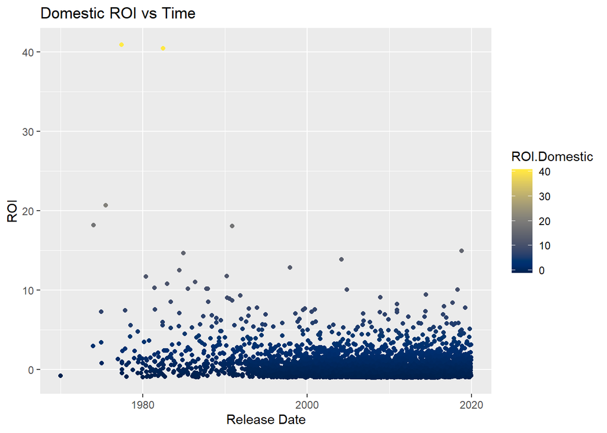

```r
ggplot(movies_ROI)+
        geom_point(mapping = aes(x = Release.Date, y = ROI.Domestic, color = ROI.Domestic))+
        labs(x =  'Release Date', y = 'ROI', title = 'Domestic ROI vs Time')+
        scale_color_viridis(option = "E")
```

We have a quite interesting plot.

What we can conclude out of this representation is that from the 70’s to the 90’s the top films by Production Budget had a more disperse range of **ROI** values that the films from the 2000’s to 2020’s.

However, is important to take into account that this list has been made based on the Production Budget, and therefore, films with less Budget might have better **ROI**.

For example, the film *The Witch of Blair* had a Production Budget of 300K USD and Domestic Gross Revenue of 140.5M USD, therefore the ROI for this films is around **466**, far over the top film of our list.

- Source: [Web Archive (Box Office Mojo)](https://web.archive.org/web/20130424120116/https://boxofficemojo.com/movies/?id=blairwitchproject.htm)

#### Evloution of the Return on Investement for the Worldwide Gross Revenue over time

Some basic stats of the **Worldwide ROI Distribution**

```r
movies_ROI %>%
        summarise( min(ROI.Worldwide), mean(ROI.Worldwide), max(ROI.Worldwide), sd(ROI.Worldwide))
```

```
##   min(ROI.Worldwide) mean(ROI.Worldwide) max(ROI.Worldwide) sd(ROI.Worldwide)
## 1         -0.9998077            1.943928           74.52028          3.822299
```

```r
movies_ROI %>%
        select(Movie.Title, ROI.Worldwide) %>%
        subset(ROI.Worldwide >40)
```

```
##                       Movie.Title ROI.Worldwide
## 3677 Star Wars Ep. IV: A New Hope      69.49073
## 3735             Les Intouchables      43.87323
## 3743   E.T. the Extra-Terrestrial      74.52028
```

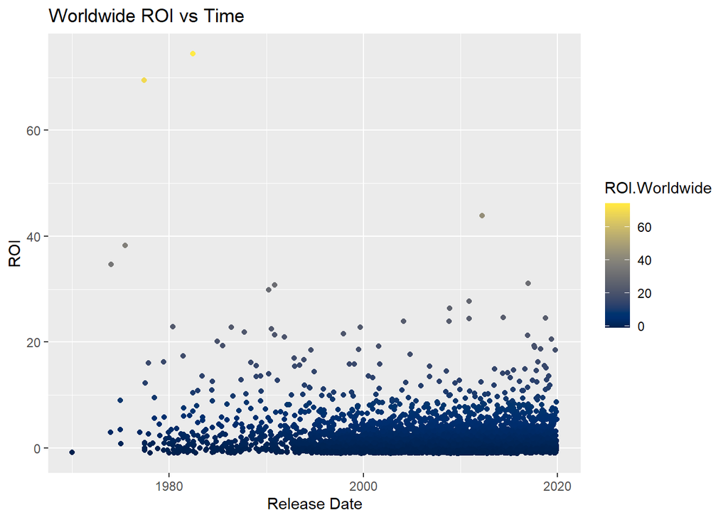

```r
ggplot(movies_ROI)+
        geom_point(mapping = aes(x = Release.Date, y = ROI.Worldwide, color = ROI.Worldwide))+
        labs(x =  'Release Date', y = 'ROI', title = 'Worldwide ROI vs Time')+
        scale_color_viridis(option = "E")
```

As in the previous case, the 70’s to the 90’s the top films by Production Budget had a more disperse range of **ROI** values that the films from the 2000’s to 2020’s.

In many cases the **ROI** values are bigger, as expected due to the increase in the total Revenue.

Another aspect that we need to consider is that as this list does not take into account inflation rate, for the older movie it is highly probable that we have an over representation of high Production Budget Movies in that range ( 70-90’s).

#### Is the Domestic Gross Revenue a potential indicator or the Worldwide Gross Revenue?

To study this we are going to represent the quotient between the Worldwide.Gross and Domestic.Gross vs time

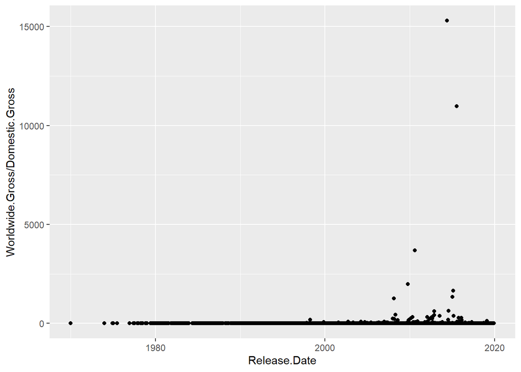

```r
ggplot(movies_ROI)+
        geom_point(mapping = aes(x = Release.Date, y = Worldwide.Gross/Domestic.Gross))
```

At first glance, we can think that we have a very low dispersity of our resultS, with just a few examples where the Worldwide.Gross does not correlate with the Domestic.Gross. Actually what we have is just a few outliers were the ratio is greater than 25.

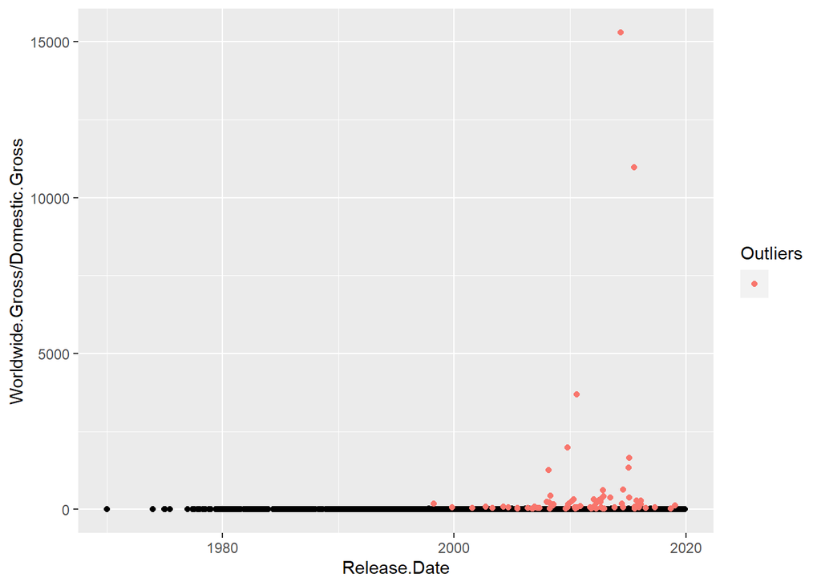

```r
movies_outliers <- movies %>%
        mutate(D_W = (Worldwide.Gross/Domestic.Gross)) %>%
        subset(D_W > 25)
ggplot()+
        geom_point(data = movies_ROI, mapping = aes(x = Release.Date, y = Worldwide.Gross/Domestic.Gross))+
        geom_point(data = movies_outliers, mapping = aes(x = Release.Date, y = D_W, color=''))+
        labs(color='Outliers')
```

Those are films that made much more profit Worldwide than Domestically (up to 15 000 times)

This is the list of Movies with over 25 more Worlwide Gross Revenue than Domestic Gross Revenue

```r
movies_outliers %>%
        select(Movie.Title, D_W) %>%
        arrange(desc(D_W))
```

```
##                                       Movie.Title         D_W
## 1                  Thunder and the House of Magic 15297.60939
## 2                                     Zhuo yao ji 10965.50055
## 3                              The Oxford Murders  3686.05684
## 4                                 St. Trinianâ\200\231s  1988.68260
## 5                            Tian jiang xiong shi  1654.10928
## 6                                       Wild Card  1348.68406
## 7  Genghis Khan: To the Ends of the Earth and Sea  1252.44039
## 8                                        Barbecue   638.05412
## 9                              Dangerous Liaisons   614.56347
## 10                                          Rogue   447.12754
## 11                                     Le prÃ©nom   410.76115
## 12                                          Trash   374.81046
## 13                                     Redemption   370.53571
## 14                                       Shanghai   333.99940
```

[output cut: 58 more lines]

If we leave those outliers out by a moment we get a very different plot.

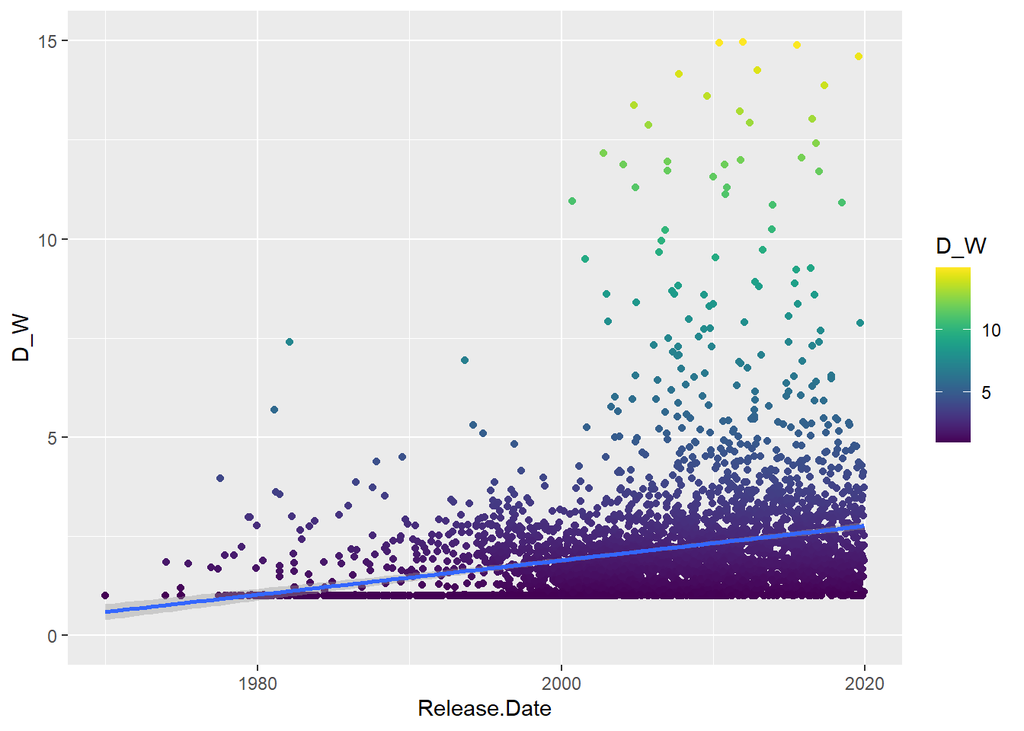

```r
movies %>%
        mutate(D_W = (Worldwide.Gross/Domestic.Gross)) %>%
        subset(D_W <= 15) %>%
        ggplot()+
                geom_point(mapping = aes(x = Release.Date, y = D_W, color = D_W))+
                geom_smooth(method = "lm", mapping = aes(x = Release.Date, y = D_W))+
                scale_color_viridis(option = "D")+
                ylim(0,15)
```

**It seems that the Domestic Gross Revenue is not a good indicator of the Worldwide performance of a film**

What we can do conclude is that the Worldwide Gross Revenue has become a major component over the Domestic Gross Revenue for High Budget films.